# T1_PSDT_11.01.2025

Irimia Mihaela

2025-01-11

## Exploratory Data Analysis of a Dataset Consisting of Seven Poems using various R libraries

### Analysis of a Dataset Consisting of Seven Poems Using NLP Tools

*Objective:* In this study, we will implement methods such as Natural Language Processing (NLP) to perform text analytics and visualization. Most of the time, the data is available in an unstructured format, and to derive insights from it, preprocessing is required. We will use NLP algorithms to read the text and extract meaningful information. Specifically, this study analyzes seven poems and generates graphical visualizations, including word distributions, word clouds, and more, using various R libraries.

In the working session, we will upload the package we need:

## Database creation

We will create our database by adding, one by one, seven poems written in English by different authors. The poems are available on the [Poetryfoundation](https://www.poetryfoundation.org/poems/) platform. The resulting database will be analyzed.

The full text poem is available [here](https://lithub.com/the-32-most-iconic-poems-in-the-english-language/) (*Still I Rise By Maya Angelou*)

The first few lines of the data are presented:

```
## [1] "You may write me down in history" "With your bitter, twisted lies,"
## [3] "You may trod me in the very dirt" "But still, like dust, I'll rise."
## [5] "Does my sassiness upset you?"     "Why are you beset with gloom?"
```

The full poem text is available [here](https://www.poetryfoundation.org/poems/43991/kubla-khan) (*Kubla Khan By Samuel Taylor Coleridge*)

The first few lines of the data are presented:

```
## [1] "In Xanadu did Kubla Khan"
## [2] "A stately pleasure-dome decree:"
## [3] "Where Alph, the sacred river, ran"
## [4] "Through caverns measureless to man"
## [5] "Down to a sunless sea."
## [6] "So twice five miles of fertile ground"
```

The first few lines of the data are presented:

```
## [1] "Turning and turning in the widening gyre"
## [2] "The falcon cannot hear the falconer;"
## [3] "Things fall apart; the centre cannot hold;"
## [4] "Mere anarchy is loosed upon the world,"
## [5] "The blood-dimmed tide is loosed, and everywhere"
## [6] "The ceremony of innocence is drowned;"
```

The full poem text is available [here](https://www.poetryfoundation.org/poems/47652/because-i-could-not-stop-for-death-479) (*Because I could not stop for Death – (479) By Emily Dickinson*)

The first few lines of the data are presented:

```
## [1] "Because I could not stop for Death –"
## [2] "He kindly stopped for me –"
## [3] "The Carriage held but just Ourselves –"
## [4] "And Immortality."
## [5] "We slowly drove – He knew no haste"
## [6] "And I had put away"
```

The full poem text is available [here](https://www.poetryfoundation.org/poems/44479/ode-to-a-nightingale) (*Ode to a Nightingale by John Keats*)

The first few lines of the data are presented:

```
## [1] "My heart aches, and a drowsy numbness pains"
## [2] "My sense, as though of hemlock I had drunk,"
## [3] "Or emptied some dull opiate to the drains"
## [4] "One minute past, and Lethe-wards had sunk:"
## [5] "'Tis not through envy of thy happy lot,"
## [6] "But being too happy in thine happiness, —"
```

The full poem text is available [here](https://www.poetryfoundation.org/poems/43997/the-rime-of-the-ancient-mariner-text-of-1834) (*The Rime of the Ancient Mariner by Samuel Taylor Coleridge*)

The first few lines of the data are presented:

```
## [1] " It is an ancient Mariner,"
## [2] "And he stoppeth one of three."
## [3] "By thy long grey beard and glittering eye,"
## [4] "Now wherefore stopp'st thou me?"
## [5] "The Bridegroom's doors are opened wide,"
## [6] "And I am next of kin;"
```

The full poem text is available [here](https://www.poetryfoundation.org/poems/45134/ode-to-the-west-wind) (*Ode to the West Wind by Percy Bysshe Shelley*)

The first few lines of the data are presented:

```
## [1] "O wild West Wind, thou breath of Autumn's being,"
## [2] "Thou, from whose unseen presence the leaves dead"
## [3] "Are driven, like ghosts from an enchanter fleeing,"
## [4] "Yellow, and black, and pale, and hectic red,"
## [5] "Pestilence-stricken multitudes: O thou,"
## [6] "Who chariotest to their dark wintry bed"
```

We will add a column with the name of the poem

|  | line | versuri | title |
| --- | --- | --- | --- |
| 1 | 1 | You may write me down in history | Still_I_Rise |
| 2 | 2 | With your bitter, twisted lies, | Still_I_Rise |
| 3 | 3 | You may trod me in the very dirt | Still_I_Rise |
| 4 | 4 | But still, like dust, I'll rise. | Still_I_Rise |
| 5 | 5 | Does my sassiness upset you? | Still_I_Rise |
| 6 | 6 | Why are you beset with gloom? | Still_I_Rise |

|  | line | versuri | title |
| --- | --- | --- | --- |
| 1 | 1 | In Xanadu did Kubla Khan | Kubla_Khan |
| 2 | 2 | A stately pleasure-dome decree: | Kubla_Khan |
| 3 | 3 | Where Alph, the sacred river, ran | Kubla_Khan |
| 4 | 4 | Through caverns measureless to man | Kubla_Khan |
| 5 | 5 | Down to a sunless sea. | Kubla_Khan |
| 6 | 6 | So twice five miles of fertile ground | Kubla_Khan |

|  | line | versuri | title |
| --- | --- | --- | --- |
| 1 | 1 | Turning and turning in the widening gyre | Song_of_Myself |
| 2 | 2 | The falcon cannot hear the falconer; | Song_of_Myself |
| 3 | 3 | Things fall apart; the centre cannot hold; | Song_of_Myself |
| 4 | 4 | Mere anarchy is loosed upon the world, | Song_of_Myself |
| 5 | 5 | The blood-dimmed tide is loosed, and everywhere | Song_of_Myself |
| 6 | 6 | The ceremony of innocence is drowned; | Song_of_Myself |

|  | line | versuri | title |
| --- | --- | --- | --- |
| 1 | 1 | Because I could not stop for Death – | Because_I_could_not_stop_for_Death |
| 2 | 2 | He kindly stopped for me – | Because_I_could_not_stop_for_Death |
| 3 | 3 | The Carriage held but just Ourselves – | Because_I_could_not_stop_for_Death |
| 4 | 4 | And Immortality. | Because_I_could_not_stop_for_Death |
| 5 | 5 | We slowly drove – He knew no haste | Because_I_could_not_stop_for_Death |
| 6 | 6 | And I had put away | Because_I_could_not_stop_for_Death |

|  | line | versuri | title |
| --- | --- | --- | --- |
| 1 | 1 | My heart aches, and a drowsy numbness pains | Ode_to_a_Nightingale |
| 2 | 2 | My sense, as though of hemlock I had drunk, | Ode_to_a_Nightingale |
| 3 | 3 | Or emptied some dull opiate to the drains | Ode_to_a_Nightingale |
| 4 | 4 | One minute past, and Lethe-wards had sunk: | Ode_to_a_Nightingale |
| 5 | 5 | 'Tis not through envy of thy happy lot, | Ode_to_a_Nightingale |
| 6 | 6 | But being too happy in thine happiness, — | Ode_to_a_Nightingale |

|  | line | versuri | title |
| --- | --- | --- | --- |
| 1 | 1 | It is an ancient Mariner, | Rime_of_the_Ancient_Mariner |
| 2 | 2 | And he stoppeth one of three. | Rime_of_the_Ancient_Mariner |
| 3 | 3 | By thy long grey beard and glittering eye, | Rime_of_the_Ancient_Mariner |
| 4 | 4 | Now wherefore stopp'st thou me? | Rime_of_the_Ancient_Mariner |
| 5 | 5 | The Bridegroom's doors are opened wide, | Rime_of_the_Ancient_Mariner |
| 6 | 6 | And I am next of kin; | Rime_of_the_Ancient_Mariner |

|  | line | versuri | title |
| --- | --- | --- | --- |
| 1 | 1 | O wild West Wind, thou breath of Autumn's being, | Ode_to_the_West_Wind |
| 2 | 2 | Thou, from whose unseen presence the leaves dead | Ode_to_the_West_Wind |
| 3 | 3 | Are driven, like ghosts from an enchanter fleeing, | Ode_to_the_West_Wind |
| 4 | 4 | Yellow, and black, and pale, and hectic red, | Ode_to_the_West_Wind |
| 5 | 5 | Pestilence-stricken multitudes: O thou, | Ode_to_the_West_Wind |
| 6 | 6 | Who chariotest to their dark wintry bed | Ode_to_the_West_Wind |

### Dataset description

The next step is to combine all created tables into one dataframe using the rbind() function.

|  | line | versuri | title |
| --- | --- | --- | --- |
| 1 | 1 | You may write me down in history | Still_I_Rise |
| 2 | 2 | With your bitter, twisted lies, | Still_I_Rise |
| 3 | 3 | You may trod me in the very dirt | Still_I_Rise |
| 4 | 4 | But still, like dust, I'll rise. | Still_I_Rise |
| 5 | 5 | Does my sassiness upset you? | Still_I_Rise |
| 6 | 6 | Why are you beset with gloom? | Still_I_Rise |

The resulting dataset (poezii) consists of seven English poems, in which each line provides information about:

1. the number of the line verse within the poem,
2. the text of the verse
3. the title of the poem to which the verse belongs

The seven poem titles from our created dataset are:

| title |
| --- |
| Still_I_Rise |
| Kubla_Khan |
| Song_of_Myself |
| Because_I_could_not_stop_for_Death |
| Ode_to_a_Nightingale |
| Rime_of_the_Ancient_Mariner |
| Ode_to_the_West_Wind |

We will transform our poem dataset into a structured format that is easier to analyze and parse at the level of individual words. The *unnest_tokens()* function from the *tidytext* package breaks the verses into individual words.

|  | line | title | word |
| --- | --- | --- | --- |
| 1 | 1 | Still_I_Rise | you |
| 2 | 1 | Still_I_Rise | may |
| 3 | 1 | Still_I_Rise | write |
| 4 | 1 | Still_I_Rise | me |
| 5 | 1 | Still_I_Rise | down |
| 6 | 1 | Still_I_Rise | in |

| title | word | n |
| --- | --- | --- |
| Rime_of_the_Ancient_Mariner | the | 46 |
| Ode_to_a_Nightingale | the | 41 |
| Ode_to_the_West_Wind | the | 33 |
| Rime_of_the_Ancient_Mariner | and | 29 |
| Ode_to_a_Nightingale | and | 26 |
| Ode_to_the_West_Wind | and | 26 |
| Ode_to_the_West_Wind | of | 20 |
| Kubla_Khan | and | 18 |
| Song_of_Myself | the | 16 |
| Kubla_Khan | a | 15 |

[output cut: 1485 more lines]

All histograms show right-skewed distributions, consistent with Zipf’s law. This means that a small number of frequent words (such as stopwords or common words) dominate, while many words appear only rarely. These less frequent words are often part of the author’s unique vocabulary and include thematic words related to nature, emotions, symbolic imagery, and similar concepts. It is important to note that stopwords were not removed from the analyzed dataset.

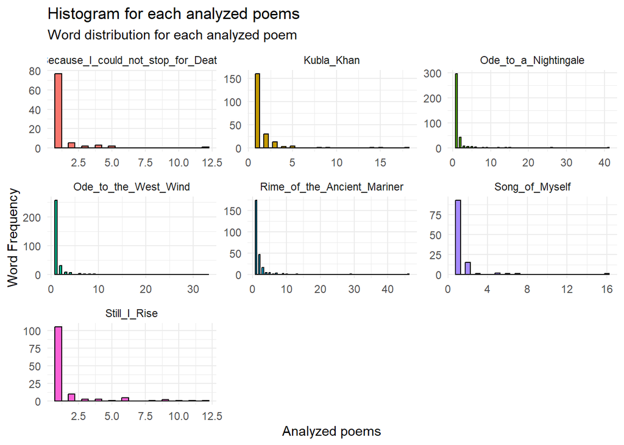

As we can see, the most frequently used word is *the*, followed by *and*, *of*, and so on.

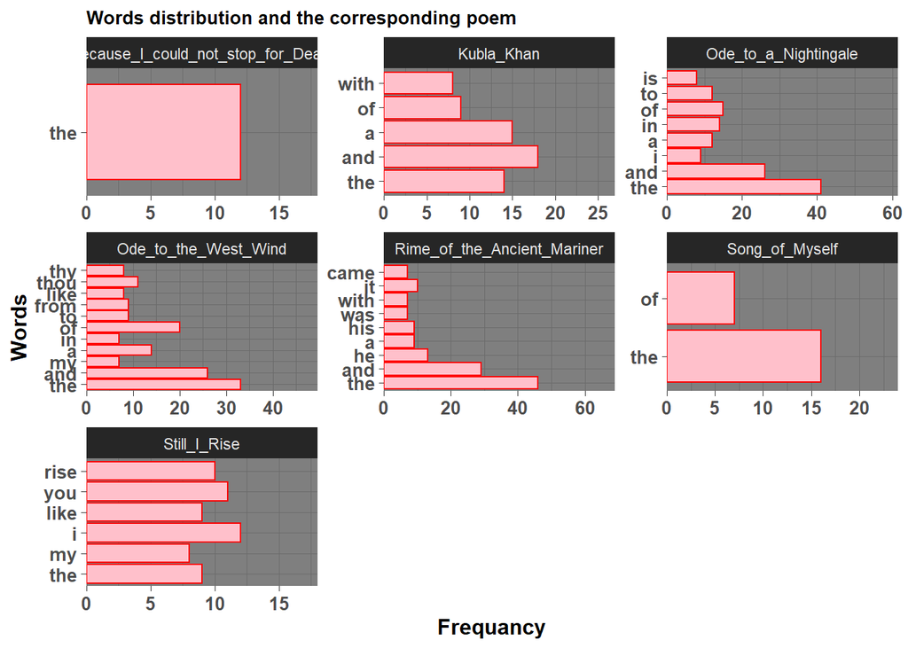

In the next step, the stopwords will be removed from the analyzed dataset, retaining only the relevant words.

| nr_linii_poezie | title | line | word |
| --- | --- | --- | --- |
| 1 | Still_I_Rise | 1 | write |
| 1 | Still_I_Rise | 1 | history |
| 2 | Still_I_Rise | 2 | bitter |
| 2 | Still_I_Rise | 2 | twisted |
| 2 | Still_I_Rise | 2 | lies |
| 3 | Still_I_Rise | 3 | trod |

| title | word | n |
| --- | --- | --- |
| Ode_to_the_West_Wind | thou | 11 |
| Still_I_Rise | rise | 10 |
| Ode_to_the_West_Wind | thy | 8 |
| Rime_of_the_Ancient_Mariner | ice | 6 |
| Kubla_Khan | dome | 5 |
| Ode_to_a_Nightingale | thee | 5 |

It can be observed that all histograms display right-skewed distributions, consistent with Zipf’s law. This means that high-frequency words, also known as common words, dominate and appear at the beginning of the distribution, while low-frequency words occur rarely and appear at the ending of the distribution.

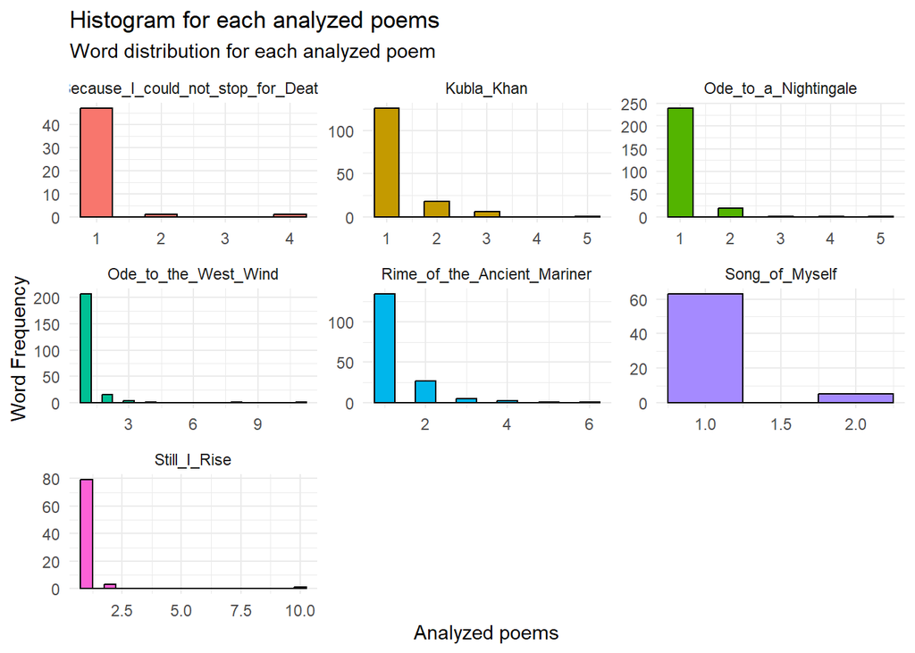

## Distribution of the words

Graphic representation of the words distribution with occurrence frequency greater than 4.

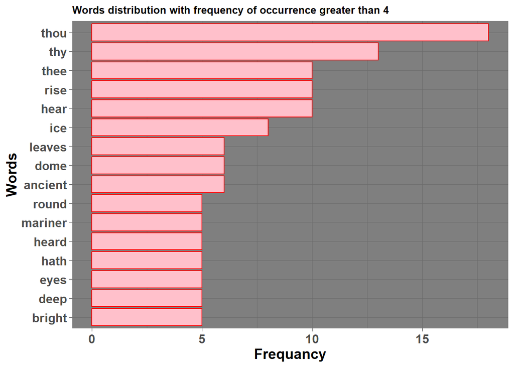

## Distribution of the words in each poem

The poem with the largest number of words is *Ode to a Nightingale* (with 297 words), followed by *Ode to the West Wind* (with 278 words), *Rime of the Ancient Mariner* (with 226 words) and so on, as we can see from the table below. At the opposite pole is poetry *Because I could not stop for Death* with 53 words.

| title | n |
| --- | --- |
| Ode_to_a_Nightingale | 297 |
| Ode_to_the_West_Wind | 278 |
| Rime_of_the_Ancient_Mariner | 226 |
| Kubla_Khan | 185 |
| Still_I_Rise | 95 |
| Song_of_Myself | 73 |
| Because_I_could_not_stop_for_Death | 53 |

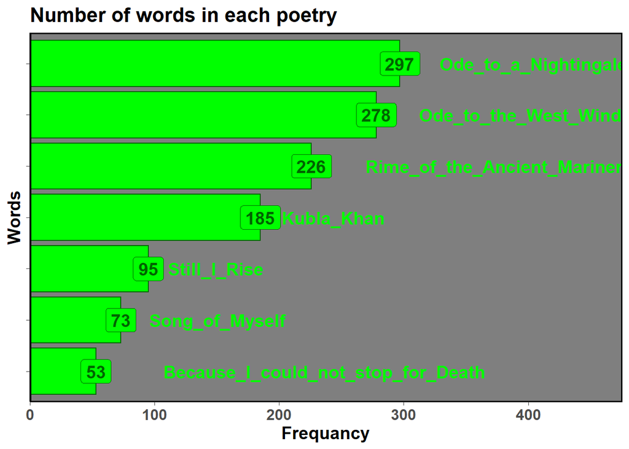

In Figure below we will present the words distribution with an occurrence frequency greater than 2 in six different poems: *Because I could not stop for Death*, *Kubla Khan*, *Ode to a Nightingale*, *Still I Rise*, etc.

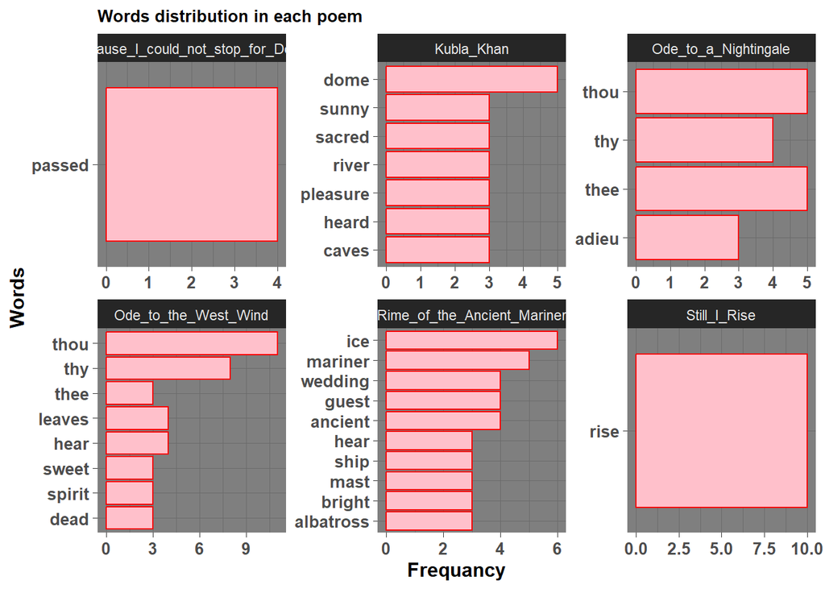

Each graphic presents the most used words (keywords) in each poem and their occurrence frequency.

## Words distribution and the corresponding poem

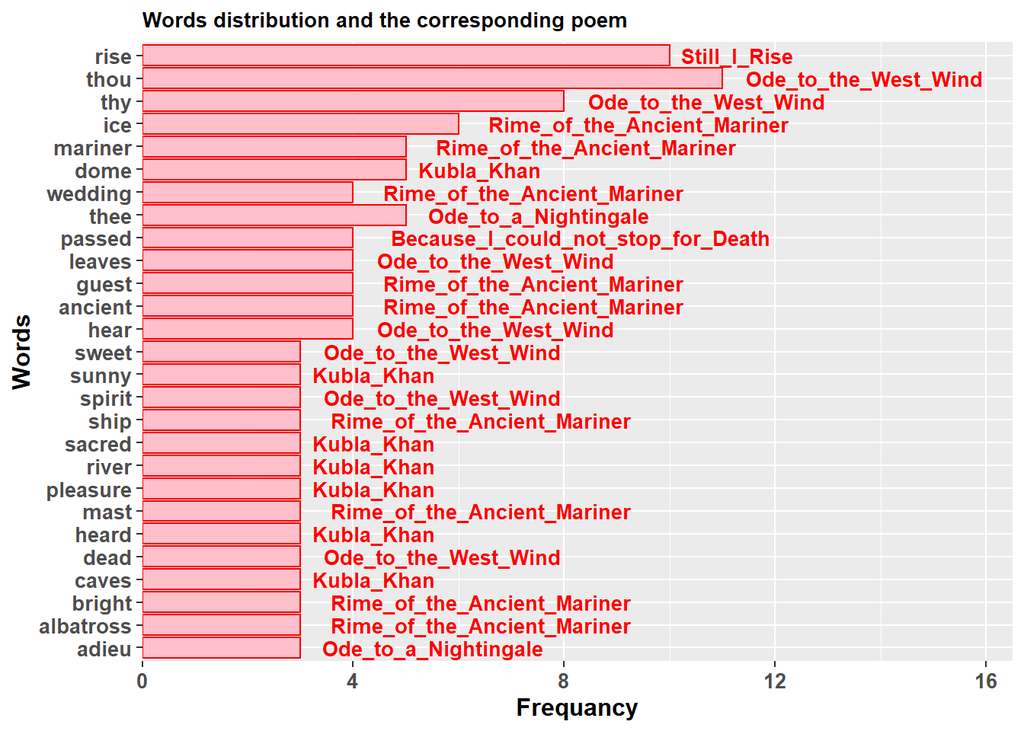

|  | title | word | n |
| --- | --- | --- | --- |
| 1 | Ode_to_the_West_Wind | thou | 11 |
| 2 | Still_I_Rise | rise | 10 |
| 3 | Ode_to_the_West_Wind | thy | 8 |
| 4 | Rime_of_the_Ancient_Mariner | ice | 6 |
| 5 | Kubla_Khan | dome | 5 |
| 6 | Ode_to_a_Nightingale | thee | 5 |
| 7 | Rime_of_the_Ancient_Mariner | mariner | 5 |
| 8 | Because_I_could_not_stop_for_Death | passed | 4 |
| 9 | Ode_to_the_West_Wind | hear | 4 |
| 10 | Ode_to_the_West_Wind | leaves | 4 |

[output cut: 5 more lines]

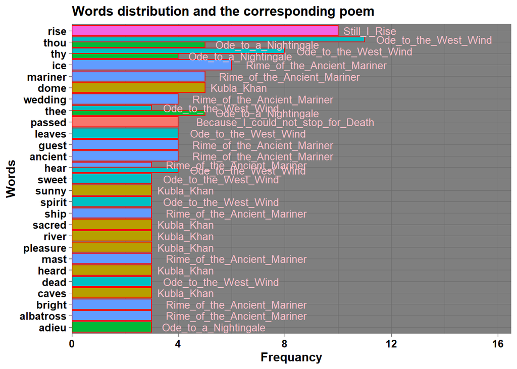

| word | freq |
| --- | --- |
| thou | 18 |
| thy | 13 |
| hear | 10 |
| rise | 10 |
| thee | 10 |
| ice | 8 |
| ancient | 6 |
| dome | 6 |
| leaves | 6 |
| bright | 5 |

[output cut: 857 more lines]

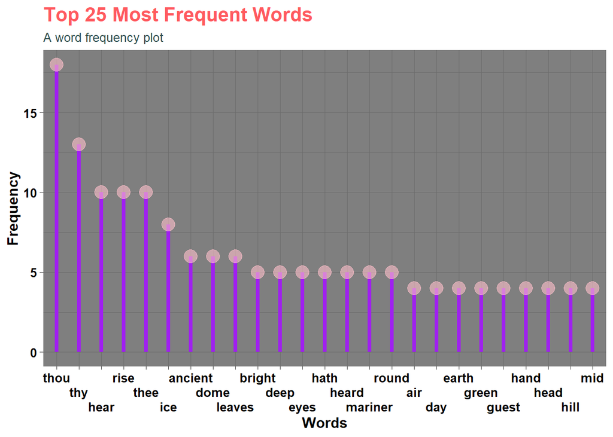

## Graphic representation of wordcloud

In order to create a word cloud, we will first calculate the term document matrix (TDM - Term-Document-Matrix), in which each title represents a document. For this reason, we will use *tm* or *tidytext* packages from R.

[output not shown]

[output cut: 107 more lines]

[output not shown]

It can be seen that the most or frequent word is *thou*, *thy*, *hear* etc.

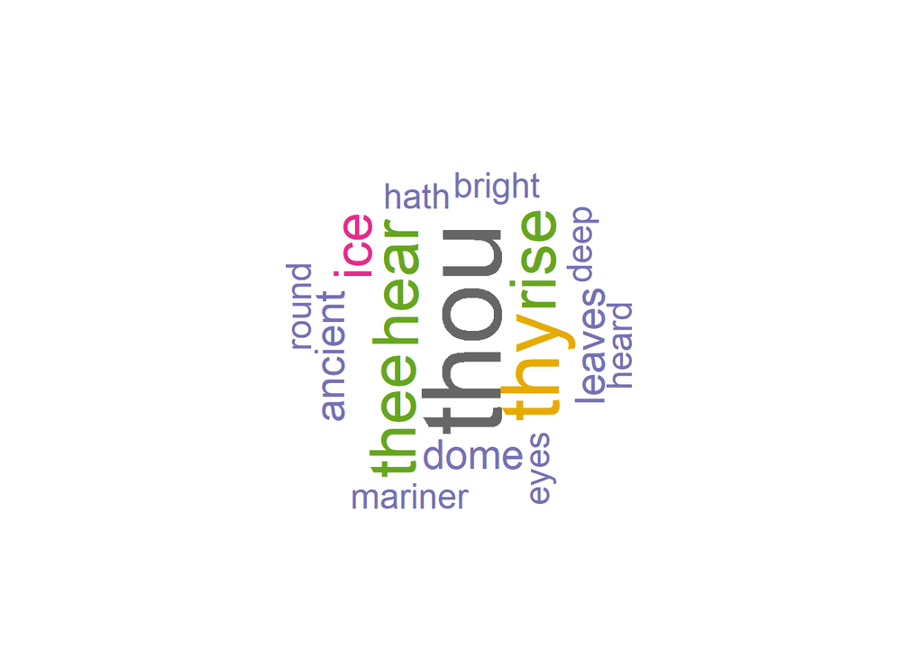

[figure not shown]

| word | title | proportion |
| --- | --- | --- |
| carriage | Because_I_could_not_stop_for_Death | 1.8867925 |
| centuries | Because_I_could_not_stop_for_Death | 1.8867925 |
| children | Because_I_could_not_stop_for_Death | 1.8867925 |
| chill | Because_I_could_not_stop_for_Death | 1.8867925 |
| civility | Because_I_could_not_stop_for_Death | 1.8867925 |
| cornice | Because_I_could_not_stop_for_Death | 1.8867925 |
| day | Because_I_could_not_stop_for_Death | 1.8867925 |
| death | Because_I_could_not_stop_for_Death | 1.8867925 |
| dews | Because_I_could_not_stop_for_Death | 1.8867925 |
| drew | Because_I_could_not_stop_for_Death | 1.8867925 |

[output cut: 8348 more lines]

| word | title | n |
| --- | --- | --- |
| air | Kubla_Khan | 1 |
| air | Ode_to_a_Nightingale | 1 |
| air | Ode_to_the_West_Wind | 1 |
| air | Still_I_Rise | 1 |
| amid | Kubla_Khan | 1 |
| amid | Ode_to_a_Nightingale | 1 |
| ancient | Kubla_Khan | 1 |
| ancient | Ode_to_a_Nightingale | 1 |
| ancient | Rime_of_the_Ancient_Mariner | 4 |
| art | Ode_to_a_Nightingale | 1 |

[output cut: 261 more lines]

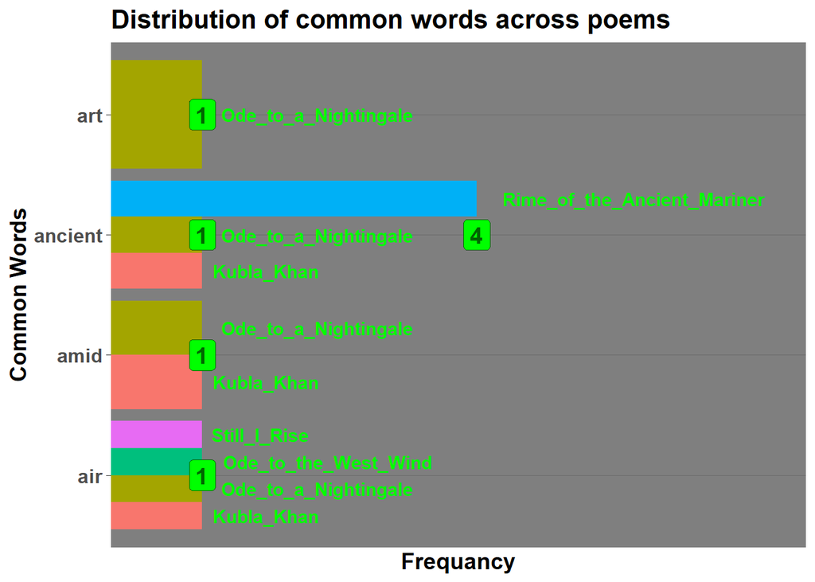

In the next step, we will graphically represent the common words across analyzed poems and compare them with the poem write by *Bysshe Shelley*. To do that, first we must find the common words from *Ode to the West Wind* poem written by *Bysshe Shelley* and the other poems:

| word | Bysshe_Shelley | author | proportion |
| --- | --- | --- | --- |
| day | 0.003597122 | Emily_Dickinson | 0.018867925 |
| quivering | 0.003597122 | Emily_Dickinson | 0.018867925 |
| air | 0.003597122 | John_Keats | 0.003367003 |
| art | 0.003597122 | John_Keats | 0.003367003 |
| boughs | 0.003597122 | John_Keats | 0.003367003 |
| breath | 0.003597122 | John_Keats | 0.003367003 |
| deep | 0.003597122 | John_Keats | 0.006734007 |
| dim | 0.003597122 | John_Keats | 0.003367003 |
| earth | 0.007194245 | John_Keats | 0.003367003 |
| flowers | 0.003597122 | John_Keats | 0.003367003 |

[output cut: 74 more lines]

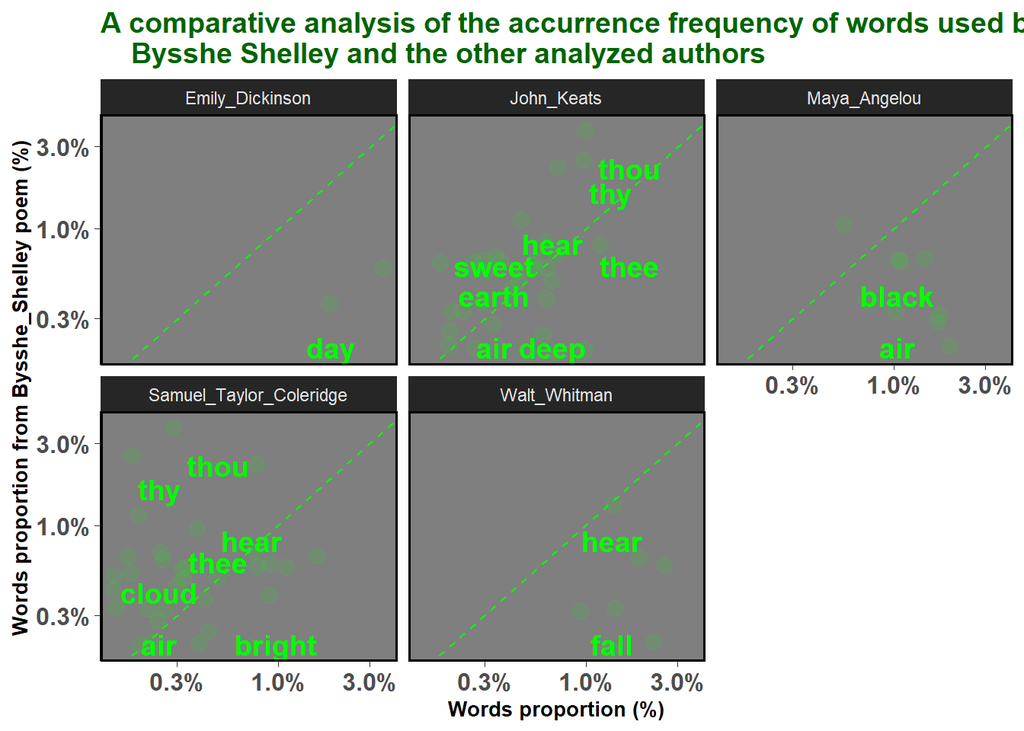

## Correlation analysis

[output not shown]

```
## The minimum relative frequency of used words by Bysshe_Shelley is:  0.003597122
```

| word | Bysshe_Shelley | author | proportion |
| --- | --- | --- | --- |
| thou | 0.039568345 | John_Keats | 0.016835017 |
| thou | 0.039568345 | Samuel_Taylor_Coleridge | 0.004866180 |
| thy | 0.028776978 | John_Keats | 0.013468013 |
| thy | 0.028776978 | Samuel_Taylor_Coleridge | 0.002433090 |
| hear | 0.014388489 | Walt_Whitman | 0.013698630 |
| hear | 0.014388489 | Samuel_Taylor_Coleridge | 0.007299270 |
| hear | 0.014388489 | John_Keats | 0.006734007 |
| leaves | 0.014388489 | John_Keats | 0.006734007 |
| thee | 0.010791367 | John_Keats | 0.016835017 |
| thee | 0.010791367 | Samuel_Taylor_Coleridge | 0.004866180 |

[output cut: 74 more lines]

As can be seen the authors that uses the same words (with frequency closer to that of words used by *Bysshe Shelley* in *Ode to the West Wind*) as *Bysshe Shelley* are: *John Keats* and *Samuel Taylor Coleridge*.

| word | Bysshe_Shelley | author | proportion |
| --- | --- | --- | --- |
| day | 0.003597122 | Emily_Dickinson | 0.018867925 |
| quivering | 0.003597122 | Emily_Dickinson | 0.018867925 |
| fall | 0.003597122 | Walt_Whitman | 0.013698630 |
| head | 0.003597122 | Walt_Whitman | 0.013698630 |
| moving | 0.003597122 | Walt_Whitman | 0.013698630 |
| sleep | 0.003597122 | Walt_Whitman | 0.013698630 |
| vast | 0.003597122 | Walt_Whitman | 0.013698630 |
| words | 0.003597122 | Walt_Whitman | 0.013698630 |
| dome | 0.003597122 | Samuel_Taylor_Coleridge | 0.012165450 |
| air | 0.003597122 | Maya_Angelou | 0.010526316 |

[output cut: 52 more lines]

```
## The minimum relative frequency of common words is:  0.00243309
```

```
## The maximum relative frequency of common words is:  0.01886792
```

## References:

1. Qiushi Yan, Notes for Text Mining with R: A Tidy Approach, 2020, https://bookdown.org/Maxine/tidy-text-mining/compare-word-frequency.html accessed on 14.01.2025.
2. https://github.com/dgrtwo/tidy-text-mining/blob/master/01-tidy-text.Rmd accessed on 14.01.2025.
3. Silge, Julia and David Robinson. “Text Mining with R: A Tidy Approach.”, 2017.